# Final Project by Wonjun Lee

```
##  [1] "X"                    "fixed.acidity"        "volatile.acidity"
##  [4] "citric.acid"          "residual.sugar"       "chlorides"
##  [7] "free.sulfur.dioxide"  "total.sulfur.dioxide" "density"
## [10] "pH"                   "sulphates"            "alcohol"
## [13] "quality"
```

# Univariate Plots Section

```
## [1] 1599   13
```

```
##        X          fixed.acidity   volatile.acidity  citric.acid
##  Min.   :   1.0   Min.   : 4.60   Min.   :0.1200   Min.   :0.000
##  1st Qu.: 400.5   1st Qu.: 7.10   1st Qu.:0.3900   1st Qu.:0.090
##  Median : 800.0   Median : 7.90   Median :0.5200   Median :0.260
##  Mean   : 800.0   Mean   : 8.32   Mean   :0.5278   Mean   :0.271
##  3rd Qu.:1199.5   3rd Qu.: 9.20   3rd Qu.:0.6400   3rd Qu.:0.420
##  Max.   :1599.0   Max.   :15.90   Max.   :1.5800   Max.   :1.000
##  residual.sugar     chlorides       free.sulfur.dioxide
##  Min.   : 0.900   Min.   :0.01200   Min.   : 1.00
##  1st Qu.: 1.900   1st Qu.:0.07000   1st Qu.: 7.00
##  Median : 2.200   Median :0.07900   Median :14.00
##  Mean   : 2.539   Mean   :0.08747   Mean   :15.87
##  3rd Qu.: 2.600   3rd Qu.:0.09000   3rd Qu.:21.00
##  Max.   :15.500   Max.   :0.61100   Max.   :72.00
##  total.sulfur.dioxide    density             pH          sulphates
##  Min.   :  6.00       Min.   :0.9901   Min.   :2.740   Min.   :0.3300
##  1st Qu.: 22.00       1st Qu.:0.9956   1st Qu.:3.210   1st Qu.:0.5500
##  Median : 38.00       Median :0.9968   Median :3.310   Median :0.6200
##  Mean   : 46.47       Mean   :0.9967   Mean   :3.311   Mean   :0.6581
##  3rd Qu.: 62.00       3rd Qu.:0.9978   3rd Qu.:3.400   3rd Qu.:0.7300
##  Max.   :289.00       Max.   :1.0037   Max.   :4.010   Max.   :2.0000
##     alcohol         quality
##  Min.   : 8.40   Min.   :3.000
##  1st Qu.: 9.50   1st Qu.:5.000
##  Median :10.20   Median :6.000
##  Mean   :10.42   Mean   :5.636
##  3rd Qu.:11.10   3rd Qu.:6.000
##  Max.   :14.90   Max.   :8.000
```

```
## 'data.frame':    1599 obs. of  13 variables:
##  $ X                   : int  1 2 3 4 5 6 7 8 9 10 ...
##  $ fixed.acidity       : num  7.4 7.8 7.8 11.2 7.4 7.4 7.9 7.3 7.8 7.5 ...
##  $ volatile.acidity    : num  0.7 0.88 0.76 0.28 0.7 0.66 0.6 0.65 0.58 0.5 ...
##  $ citric.acid         : num  0 0 0.04 0.56 0 0 0.06 0 0.02 0.36 ...
##  $ residual.sugar      : num  1.9 2.6 2.3 1.9 1.9 1.8 1.6 1.2 2 6.1 ...
##  $ chlorides           : num  0.076 0.098 0.092 0.075 0.076 0.075 0.069 0.065 0.073 0.071 ...
##  $ free.sulfur.dioxide : num  11 25 15 17 11 13 15 15 9 17 ...
##  $ total.sulfur.dioxide: num  34 67 54 60 34 40 59 21 18 102 ...
##  $ density             : num  0.998 0.997 0.997 0.998 0.998 ...
##  $ pH                  : num  3.51 3.2 3.26 3.16 3.51 3.51 3.3 3.39 3.36 3.35 ...
##  $ sulphates           : num  0.56 0.68 0.65 0.58 0.56 0.56 0.46 0.47 0.57 0.8 ...
##  $ alcohol             : num  9.4 9.8 9.8 9.8 9.4 9.4 9.4 10 9.5 10.5 ...
##  $ quality             : int  5 5 5 6 5 5 5 7 7 5 ...
```

There are 13 variables with 1599 observations. Plotting a histogram for each variable will be helpful in understanding the data set.

### Fixed Acidity

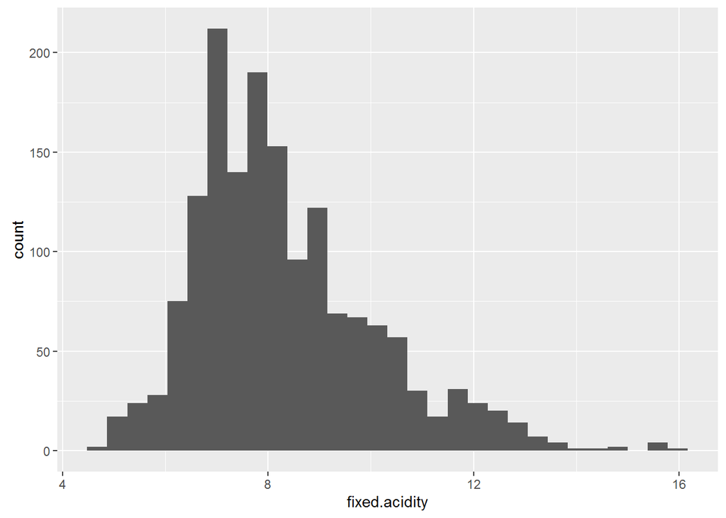

```r
ggplot(aes(x=fixed.acidity), data=df) +
  geom_histogram()
```

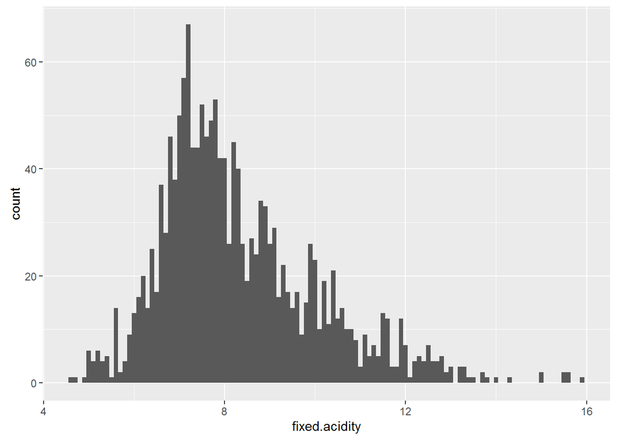

```r
ggplot(aes(x=fixed.acidity), data=df) +
  geom_histogram(binwidth=.1)
```

### Volatile Acidity

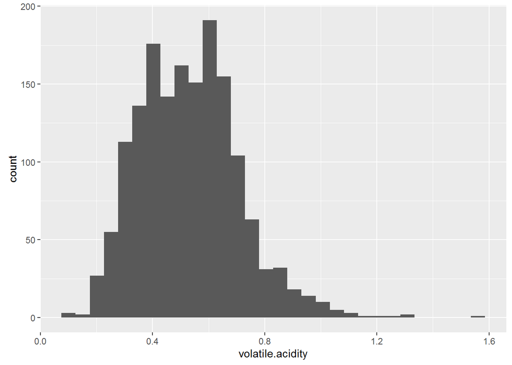

```r
ggplot(aes(x=volatile.acidity), data=df) +
  geom_histogram()
```

### Citric Acidity

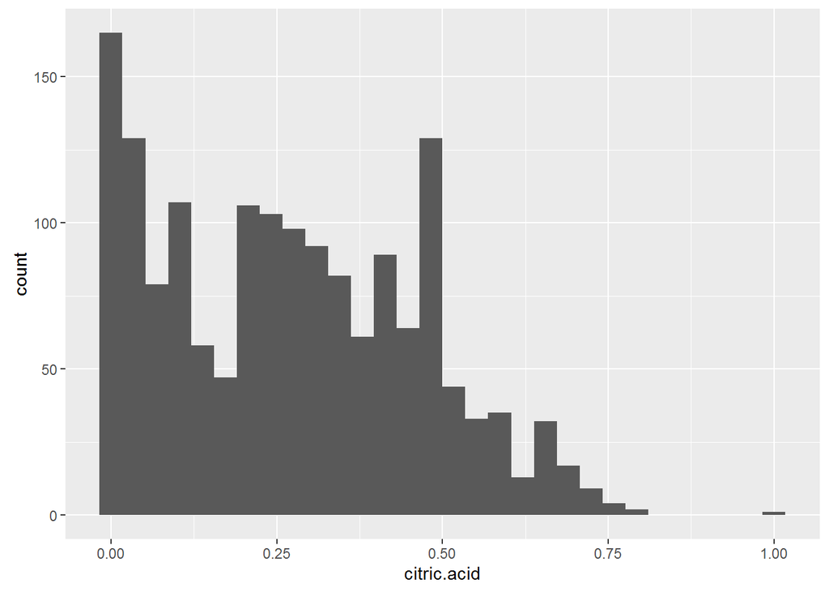

```r
ggplot(aes(x=citric.acid), data=df) +
  geom_histogram()
```

It looks right skewed graph but more thorough analysis will be helpful.

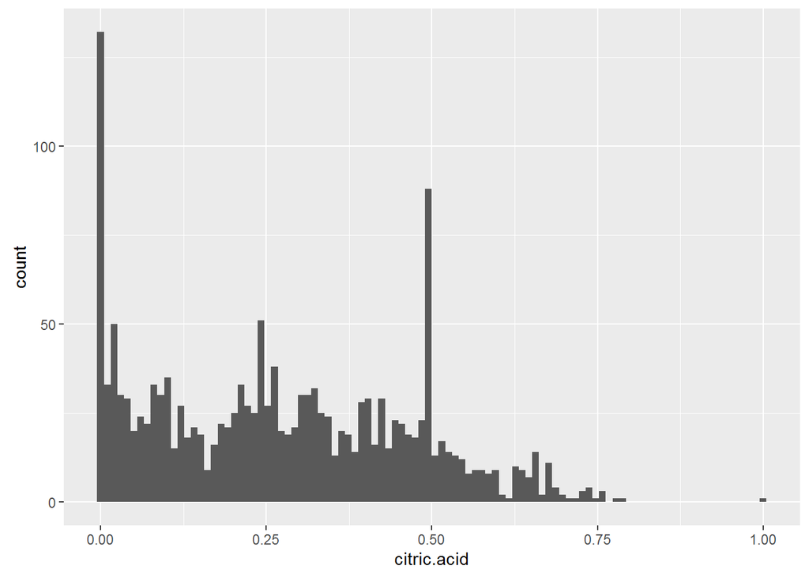

```r
ggplot(aes(x=citric.acid), data=df) +
  geom_histogram(bins=100)
```

This is very intersting graph because there are huge count at 0.00 and 0.50. More analysis might reveal interesting things.

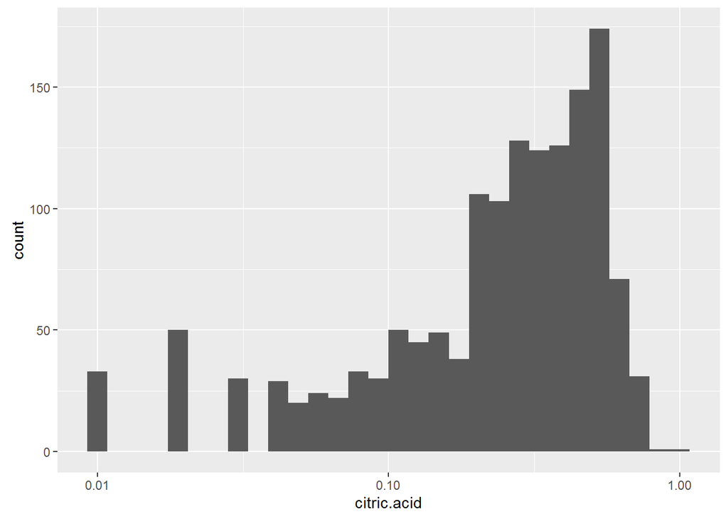

```r
ggplot(aes(x=citric.acid), data=df) +
  geom_histogram() +
  scale_x_log10()
```

After log10 is applied to citric acid, there are still many gabs before .10.

### Residual Sugar

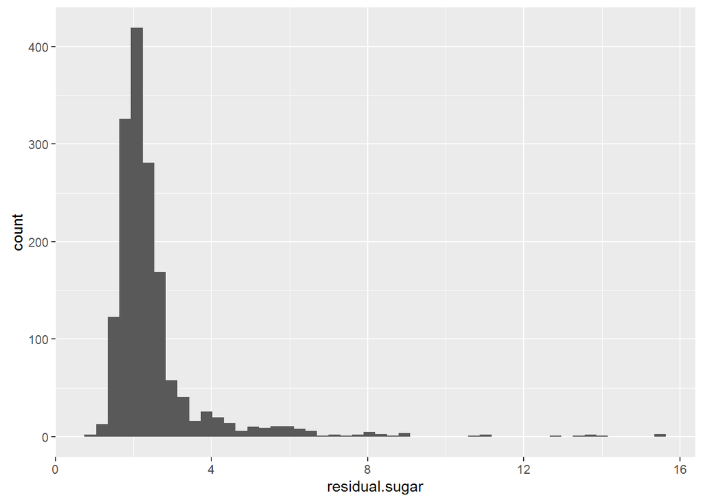

```r
ggplot(aes(x=residual.sugar), data=df) +
  geom_histogram(bins=50)
```

The graph has many outliers after 10. Using subset, anything above 10 is excluded and graphed again.

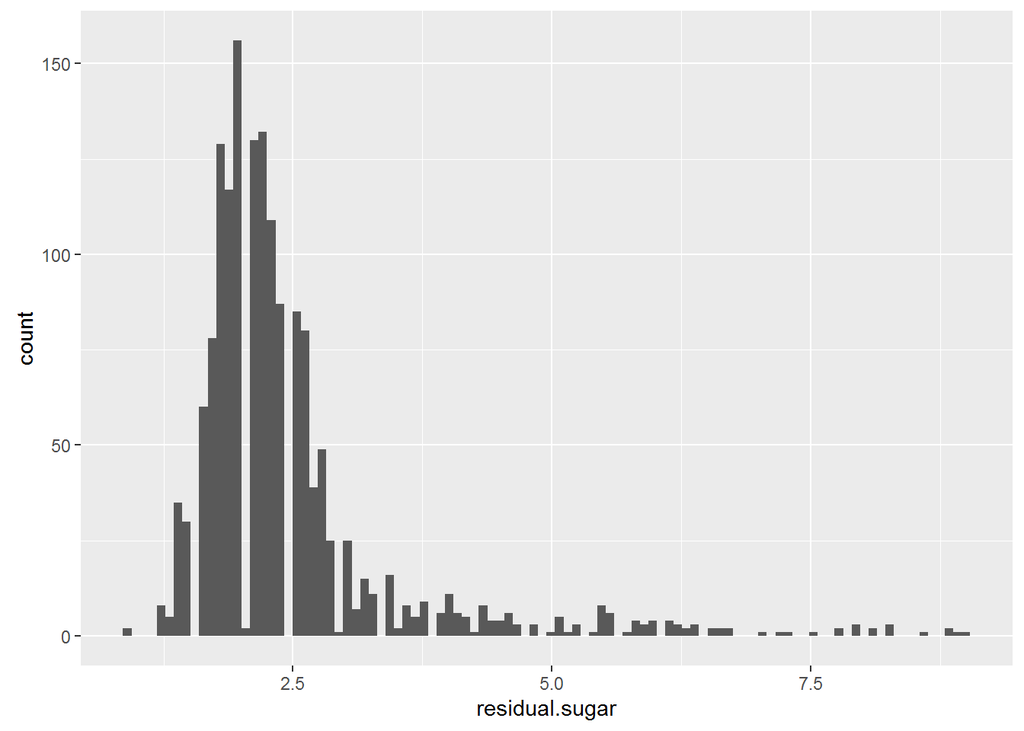

```r
ggplot(aes(x=residual.sugar), data=subset(df,residual.sugar<10)) +
  geom_histogram(bins=100)
```

Still the graph is right skewed.

### Chlorides

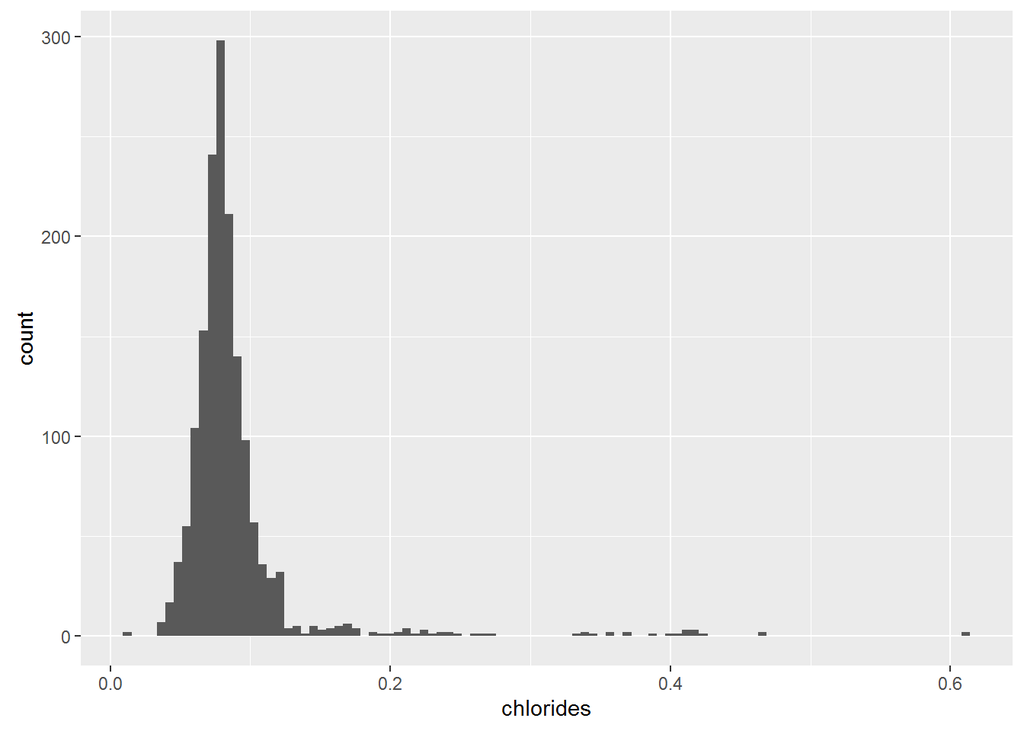

```r
ggplot(aes(x=chlorides), data=df) +
  geom_histogram(bins=100)
```

This variable also has many outliers after 0.25. Such outliers are taken out.

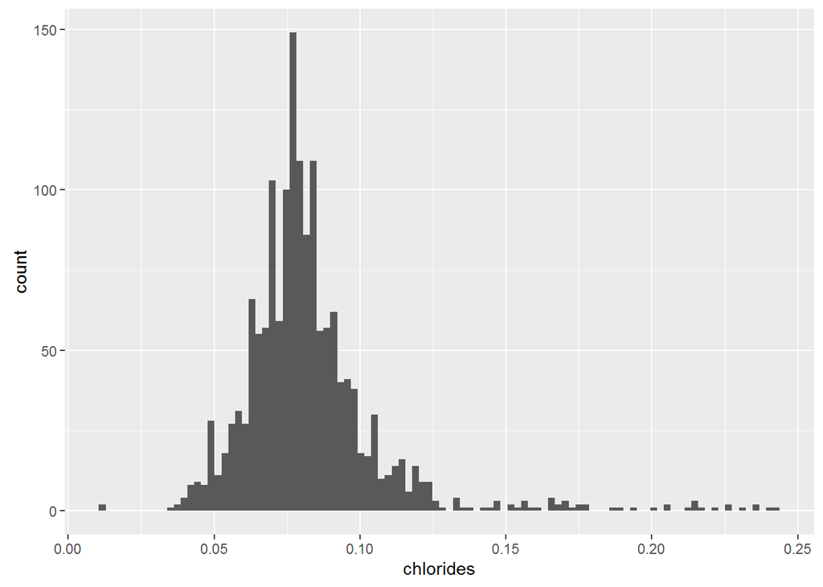

```r
ggplot(aes(x=chlorides), data=subset(df,chlorides<.25)) +
  geom_histogram(bins=100)
```

Most of the chlorides are between .05 and .10.

```r
#install.packages("dplyr")
library(dplyr)
dim(df)
```

```
## [1] 1599   13
```

```r
df %>%
  filter(chlorides>.15) %>%
  summarise(n=n())
```

```
##    n
## 1 67
```

There are total 1599 observations and only 67 observations that are larger than .15.

### Free Sulfur Dioxide

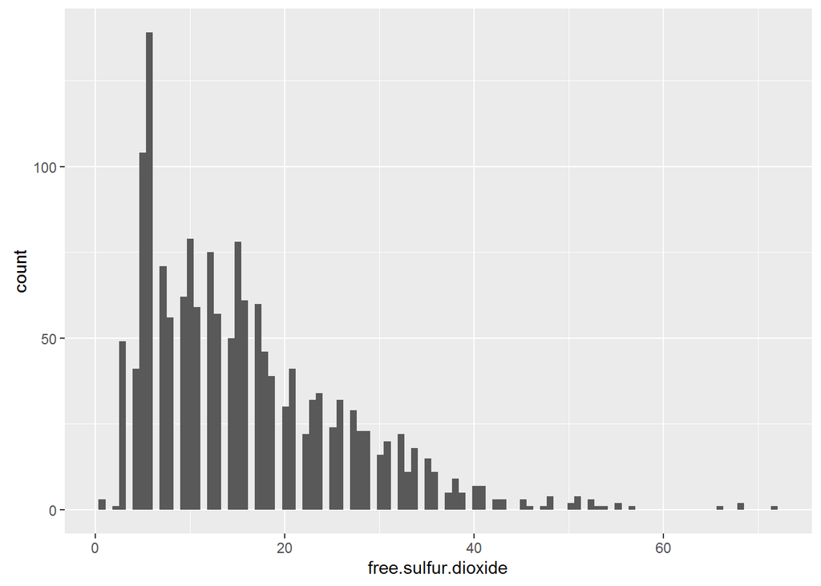

```r
ggplot(aes(x=free.sulfur.dioxide), data=df) +
  geom_histogram(bins=100)
```

### Density

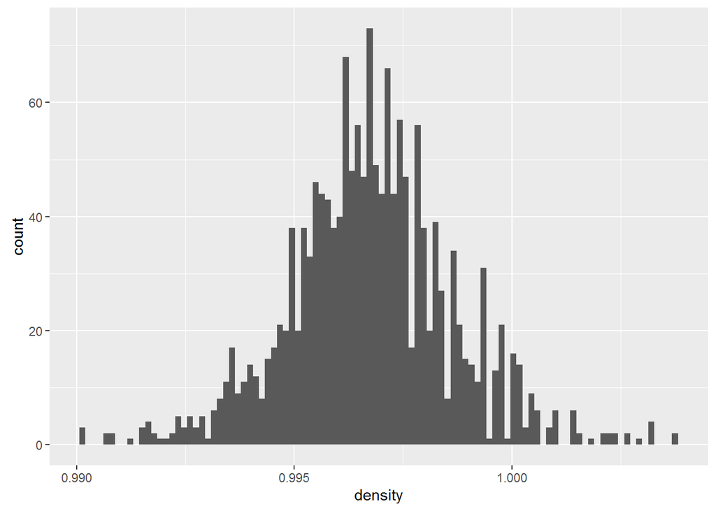

```r
ggplot(aes(x=density), data=df) +
  geom_histogram(bins=100)
```

### pH

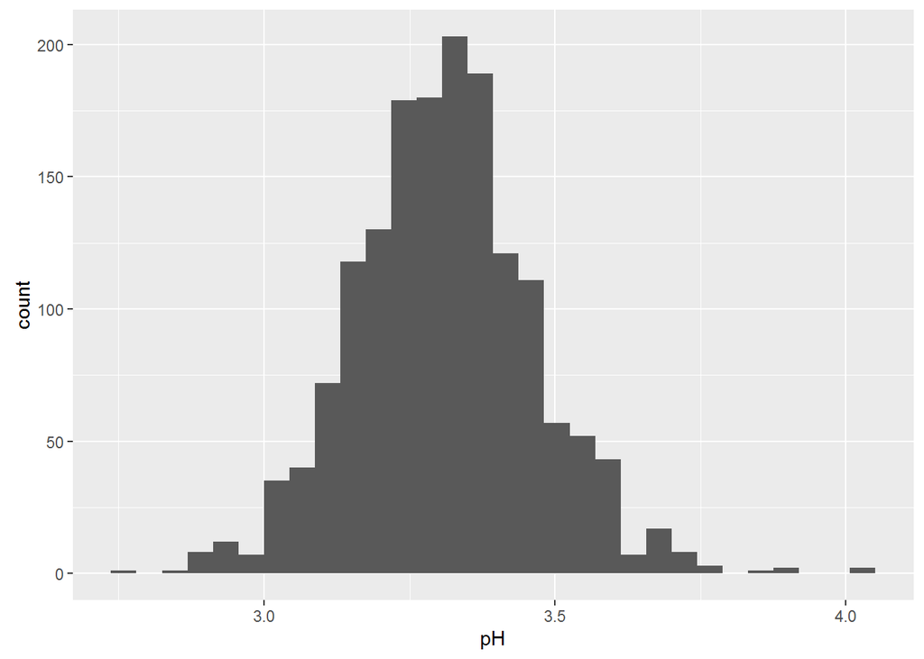

```r
ggplot(aes(x=pH), data=df) +
  geom_histogram()
```

### Sulphates

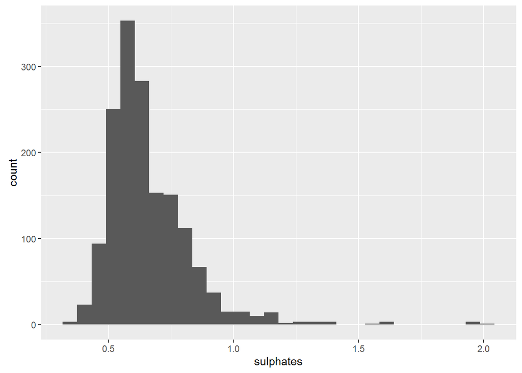

```r
ggplot(aes(x=sulphates), data=df) +
  geom_histogram()
```

### Alcohol

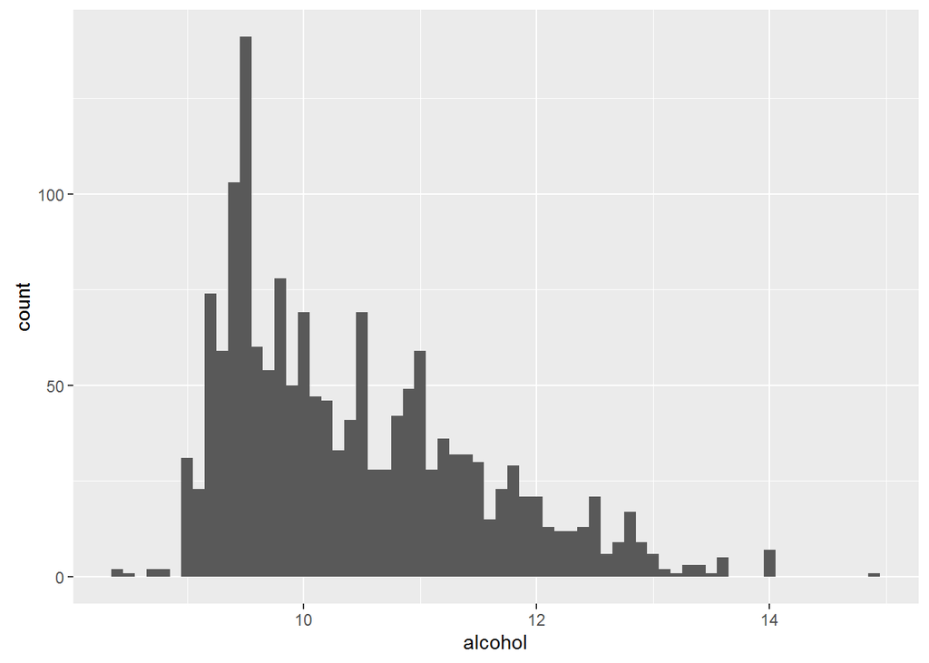

```r
ggplot(aes(x=alcohol), data=df) +
  geom_histogram(binwidth=.1)
```

### Quality

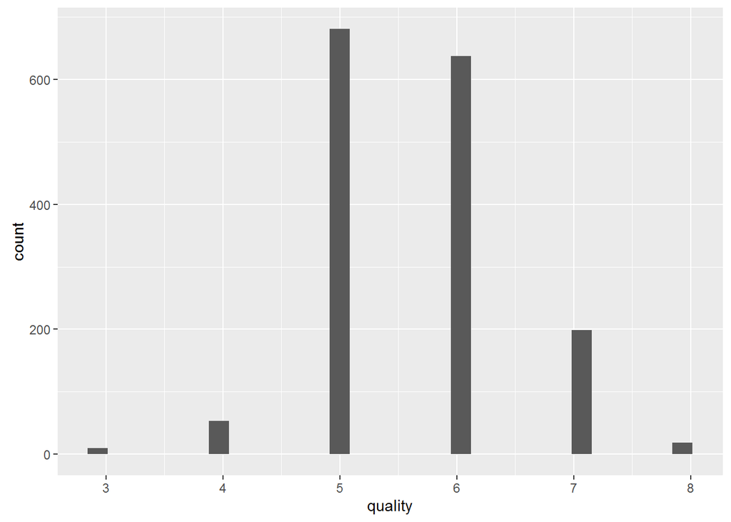

```r
ggplot(aes(x=quality), data=df) +
  geom_histogram()
```

### More graphs with density and quality

I got interested in the relationship between the density and the quality.

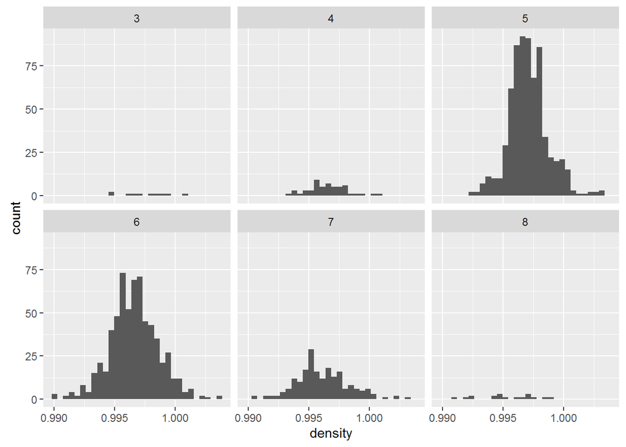

```r
ggplot(aes(x=density),data=df) +
  geom_histogram() +
  facet_wrap(~quality)
```

```r
table(df$quality)
```

```
##
##   3   4   5   6   7   8
##  10  53 681 638 199  18
```

Facet wrap shows that most of wines have qualities of 5 and 6. The summary shows that there are not many quality of 3 and 8. However, regardless of the quality of the wine, the density is usually .996.

```r
df %>%
  group_by(quality) %>%
  summarise(mean=mean(density))
```

```
## Source: local data frame [6 x 2]
##
##   quality      mean
##     (int)     (dbl)
## 1       3 0.9974640
## 2       4 0.9965425
## 3       5 0.9971036
## 4       6 0.9966151
## 5       7 0.9961043
## 6       8 0.9952122
```

The means are very close to each other.

# Univariate Analysis

### What is the structure of your dataset?

There are 1599 observations and 13 variables.

```r
str(df)
```

```
## 'data.frame':    1599 obs. of  13 variables:
##  $ X                   : int  1 2 3 4 5 6 7 8 9 10 ...
##  $ fixed.acidity       : num  7.4 7.8 7.8 11.2 7.4 7.4 7.9 7.3 7.8 7.5 ...
##  $ volatile.acidity    : num  0.7 0.88 0.76 0.28 0.7 0.66 0.6 0.65 0.58 0.5 ...
##  $ citric.acid         : num  0 0 0.04 0.56 0 0 0.06 0 0.02 0.36 ...
##  $ residual.sugar      : num  1.9 2.6 2.3 1.9 1.9 1.8 1.6 1.2 2 6.1 ...
##  $ chlorides           : num  0.076 0.098 0.092 0.075 0.076 0.075 0.069 0.065 0.073 0.071 ...
##  $ free.sulfur.dioxide : num  11 25 15 17 11 13 15 15 9 17 ...
##  $ total.sulfur.dioxide: num  34 67 54 60 34 40 59 21 18 102 ...
##  $ density             : num  0.998 0.997 0.997 0.998 0.998 ...
##  $ pH                  : num  3.51 3.2 3.26 3.16 3.51 3.51 3.3 3.39 3.36 3.35 ...
##  $ sulphates           : num  0.56 0.68 0.65 0.58 0.56 0.56 0.46 0.47 0.57 0.8 ...
##  $ alcohol             : num  9.4 9.8 9.8 9.8 9.4 9.4 9.4 10 9.5 10.5 ...
##  $ quality             : int  5 5 5 6 5 5 5 7 7 5 ...
```

Quality is the only ordered factor variable with the following levels.

```r
table(df$quality)
```

```
##
##   3   4   5   6   7   8
##  10  53 681 638 199  18
```

### What is/are the main feature(s) of interest in your dataset?

I am interested in finding which variable affects the quality the most. Then I will find the value of each variable that defines the best quality of wines.

### What other features in the dataset do you think will help support your investigation into your feature(s) of interest?

Density is already checked and density shows the similar pattern regardless of the quality. So other variables have to be analyzed.

### Did you create any new variables from existing variables in the dataset?

According to the description of the data set, the citric acid adds freshness to wines, residual sugar adds sweet and volatile acidity adds unpleasant taste to wines. I thought that ratio of the sum of citric acid and residual sugar to volatile acidity might be interesting so I created the ratio of interest as below.

```r
# Checking if there is any zero in volatile.acidity
df %>%
  filter(df$volatile.acidity == 0) %>%
  summarise(n=n())
```

```
##   n
## 1 0
```

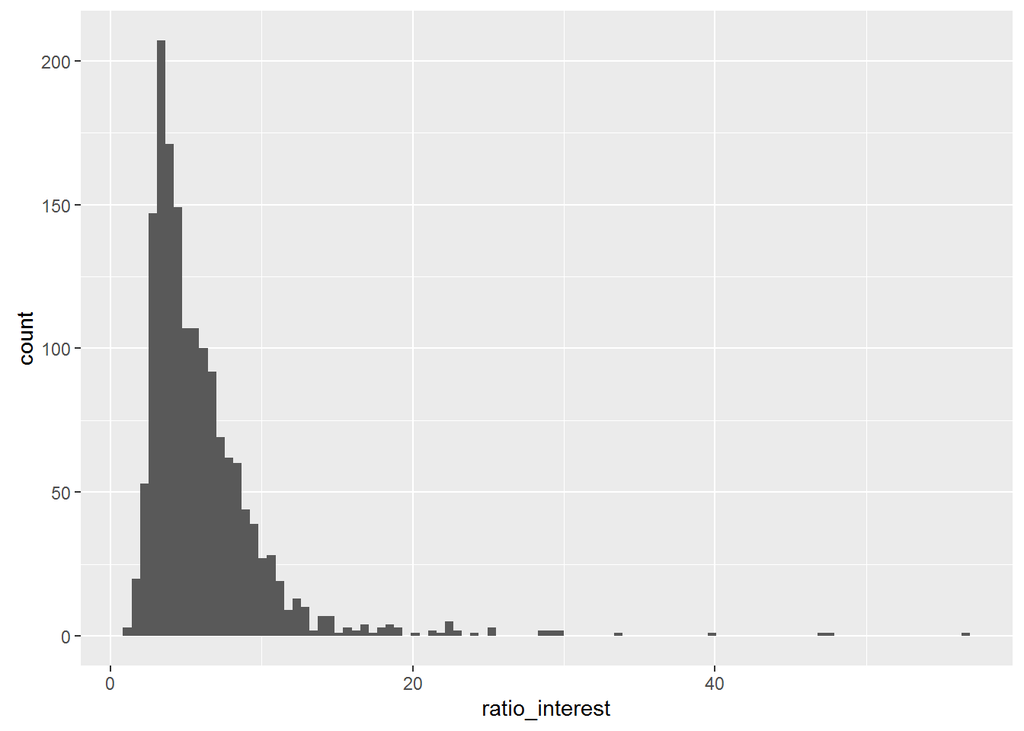

```r
# Creating New Variable
df$ratio_interest <- (df$citric.acid + df$residual.sugar) / df$volatile.acidity

# Graphing a histogram
ggplot(aes(x=ratio_interest), data=df) +
  geom_histogram(bins=100)
```

### Of the features you investigated, were there any unusual distributions? Did you perform any operations on the data to tidy, adjust, or change the form of the data? If so, why did you do this?

When creating the new variable, since the variable is a fraction, the denominator has to be nonzero values. After checking with dplyr library, there is no zero in volatile acidity.

# Bivariate Plots Section

```
##                      fixed.acidity volatile.acidity citric.acid
## fixed.acidity           1.00000000     -0.256130895  0.67170343
## volatile.acidity       -0.25613089      1.000000000 -0.55249568
## citric.acid             0.67170343     -0.552495685  1.00000000
## residual.sugar          0.11477672      0.001917882  0.14357716
## chlorides               0.09370519      0.061297772  0.20382291
## free.sulfur.dioxide    -0.15379419     -0.010503827 -0.06097813
## total.sulfur.dioxide   -0.11318144      0.076470005  0.03553302
## density                 0.66804729      0.022026232  0.36494718
## pH                     -0.68297819      0.234937294 -0.54190414
## sulphates               0.18300566     -0.260986685  0.31277004
## alcohol                -0.06166827     -0.202288027  0.10990325
## ratio_interest          0.27802275     -0.535035327  0.48712815
##                      residual.sugar    chlorides free.sulfur.dioxide
## fixed.acidity           0.114776724  0.093705186        -0.153794193
## volatile.acidity        0.001917882  0.061297772        -0.010503827
## citric.acid             0.143577162  0.203822914        -0.060978129
## residual.sugar          1.000000000  0.055609535         0.187048995
## chlorides               0.055609535  1.000000000         0.005562147
## free.sulfur.dioxide     0.187048995  0.005562147         1.000000000
## total.sulfur.dioxide    0.203027882  0.047400468         0.667666450
## density                 0.355283371  0.200632327        -0.021945831
## pH                     -0.085652422 -0.265026131         0.070377499
## sulphates               0.005527121  0.371260481         0.051657572
## alcohol                 0.042075437 -0.221140545        -0.069408354
## ratio_interest          0.753628989  0.008984994         0.099067684
##                      total.sulfur.dioxide     density          pH
## fixed.acidity                 -0.11318144  0.66804729 -0.68297819
## volatile.acidity               0.07647000  0.02202623  0.23493729
## citric.acid                    0.03553302  0.36494718 -0.54190414
## residual.sugar                 0.20302788  0.35528337 -0.08565242
## chlorides                      0.04740047  0.20063233 -0.26502613
## free.sulfur.dioxide            0.66766645 -0.02194583  0.07037750
## total.sulfur.dioxide           1.00000000  0.07126948 -0.06649456
## density                        0.07126948  1.00000000 -0.34169933
## pH                            -0.06649456 -0.34169933  1.00000000
## sulphates                      0.04294684  0.14850641 -0.19664760
## alcohol                       -0.20565394 -0.49617977  0.20563251
## ratio_interest                 0.09357047  0.24262424 -0.21403243
##                         sulphates     alcohol ratio_interest
## fixed.acidity         0.183005664 -0.06166827    0.278022749
## volatile.acidity     -0.260986685 -0.20228803   -0.535035327
## citric.acid           0.312770044  0.10990325    0.487128149
## residual.sugar        0.005527121  0.04207544    0.753628989
## chlorides             0.371260481 -0.22114054    0.008984994
## free.sulfur.dioxide   0.051657572 -0.06940835    0.099067684
## total.sulfur.dioxide  0.042946836 -0.20565394    0.093570466
## density               0.148506412 -0.49617977    0.242624235
## pH                   -0.196647602  0.20563251   -0.214032429
## sulphates             1.000000000  0.09359475    0.162314849
## alcohol               0.093594750  1.00000000    0.175360159
## ratio_interest        0.162314849  0.17536016    1.000000000
```

[figure not shown]

First of all of acidic variables (fixed.acidity and citric.acid) are negatively correlated to pH. This is very reasonable because low pH value means high acidic value.

```r
df$quality <- factor(df$quality,labels=c(3,4,5,6,7,8))

str(df)
```

```
## 'data.frame':    1599 obs. of  14 variables:
##  $ X                   : int  1 2 3 4 5 6 7 8 9 10 ...
##  $ fixed.acidity       : num  7.4 7.8 7.8 11.2 7.4 7.4 7.9 7.3 7.8 7.5 ...
##  $ volatile.acidity    : num  0.7 0.88 0.76 0.28 0.7 0.66 0.6 0.65 0.58 0.5 ...
##  $ citric.acid         : num  0 0 0.04 0.56 0 0 0.06 0 0.02 0.36 ...
##  $ residual.sugar      : num  1.9 2.6 2.3 1.9 1.9 1.8 1.6 1.2 2 6.1 ...
##  $ chlorides           : num  0.076 0.098 0.092 0.075 0.076 0.075 0.069 0.065 0.073 0.071 ...
##  $ free.sulfur.dioxide : num  11 25 15 17 11 13 15 15 9 17 ...
##  $ total.sulfur.dioxide: num  34 67 54 60 34 40 59 21 18 102 ...
##  $ density             : num  0.998 0.997 0.997 0.998 0.998 ...
##  $ pH                  : num  3.51 3.2 3.26 3.16 3.51 3.51 3.3 3.39 3.36 3.35 ...
##  $ sulphates           : num  0.56 0.68 0.65 0.58 0.56 0.56 0.46 0.47 0.57 0.8 ...
##  $ alcohol             : num  9.4 9.8 9.8 9.8 9.4 9.4 9.4 10 9.5 10.5 ...
##  $ quality             : Factor w/ 6 levels "3","4","5","6",..: 3 3 3 4 3 3 3 5 5 3 ...
##  $ ratio_interest      : num  2.71 2.95 3.08 8.79 2.71 ...
```

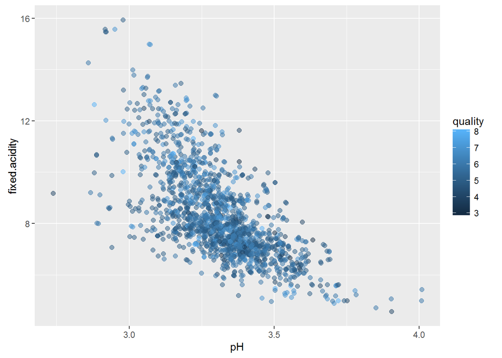

```r
ggplot(aes(x=pH,y=fixed.acidity,color=quality), data=df_sample) +
  geom_point(alpha = 0.5, size = 2, position = 'jitter') +
  scale_fill_brewer(type = 'div')
```

```r
cor.test(df$pH, df$fixed.acidity)
```

```
##
##  Pearson's product-moment correlation
##
## data:  df$pH and df$fixed.acidity
## t = -37.366, df = 1597, p-value < 2.2e-16
## alternative hypothesis: true correlation is not equal to 0
## 95 percent confidence interval:
##  -0.7082857 -0.6559174
## sample estimates:
##        cor
## -0.6829782
```

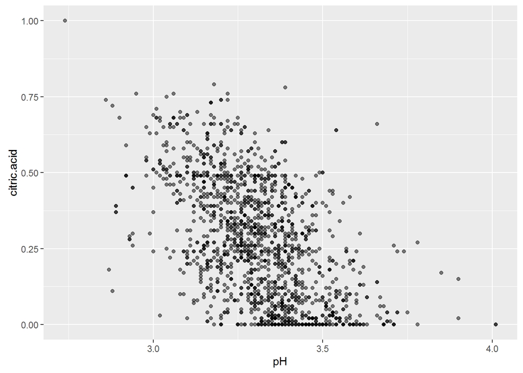

```r
ggplot(aes(x=pH,y=citric.acid),data=df_sample) +
  geom_point(alpha=.5)
```

```r
cor.test(df$pH, df$citric.acid)
```

```
##
##  Pearson's product-moment correlation
##
## data:  df$pH and df$citric.acid
## t = -25.767, df = 1597, p-value < 2.2e-16
## alternative hypothesis: true correlation is not equal to 0
## 95 percent confidence interval:
##  -0.5756337 -0.5063336
## sample estimates:
##        cor
## -0.5419041
```

Density is positively correlated to fixed.acidity and citric.acid and negatively correlated to alcohol.

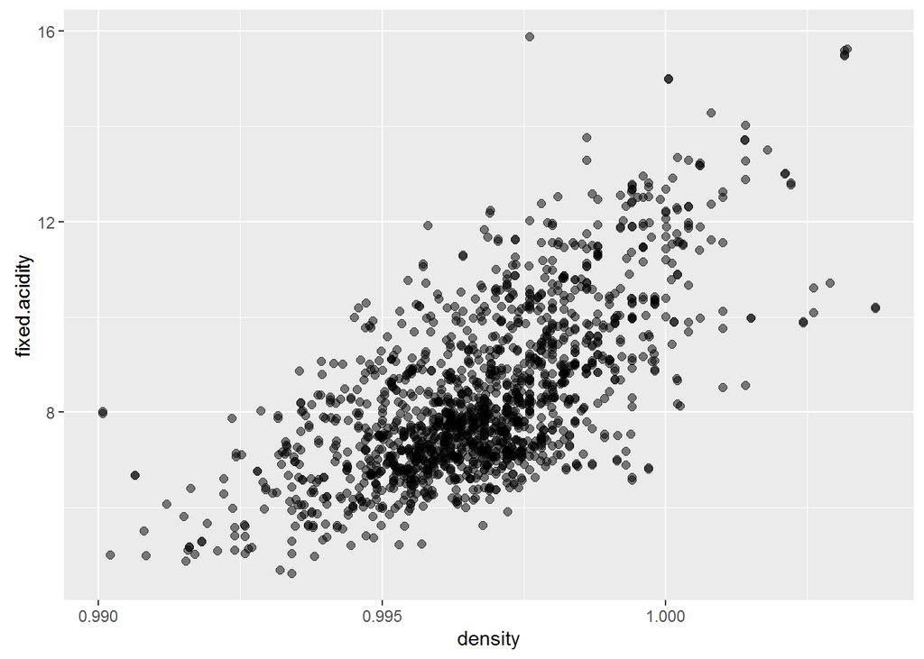

```r
ggplot(aes(x=density,y=fixed.acidity), data=df) +
  geom_point(alpha=0.5, size=2, position='jitter')
```

```r
cor.test(df$density, df$fixed.acidity)
```

```
##
##  Pearson's product-moment correlation
##
## data:  df$density and df$fixed.acidity
## t = 35.877, df = 1597, p-value < 2.2e-16
## alternative hypothesis: true correlation is not equal to 0
## 95 percent confidence interval:
##  0.6399847 0.6943302
## sample estimates:
##       cor
## 0.6680473
```

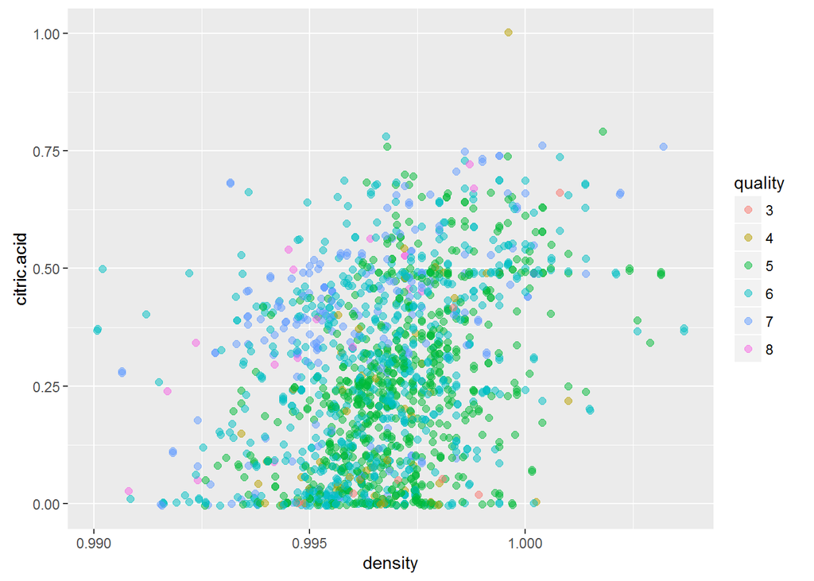

```r
ggplot(aes(x=density,y=citric.acid,color=quality), data=df) +
  geom_point(alpha=0.5, size=2, position='jitter')
```

```r
cor.test(df$density, df$citric.acid)
```

```
##
##  Pearson's product-moment correlation
##
## data:  df$density and df$citric.acid
## t = 15.665, df = 1597, p-value < 2.2e-16
## alternative hypothesis: true correlation is not equal to 0
## 95 percent confidence interval:
##  0.3216809 0.4066925
## sample estimates:
##       cor
## 0.3649472
```

citric acid is not correlated to density as much as fixed acidity.

# Bivariate Analysis

### Talk about some of the relationships you observed in this part of the investigation. How did the feature(s) of interest vary with other features in the dataset?

### Did you observe any interesting relationships between the other features (not the main feature(s) of interest)?

### What was the strongest relationship you found?

# Multivariate Plots Section

# Multivariate Analysis

### Talk about some of the relationships you observed in this part of the investigation. Were there features that strengthened each other in terms of looking at your feature(s) of interest?

### Were there any interesting or surprising interactions between features?

### OPTIONAL: Did you create any models with your dataset? Discuss the strengths and limitations of your model.

# Final Plots and Summary

### Description Three

# Reflection